# Lab 7

Author

Giovanni Librizzi

# Revision

I made a mistake on Part 2 Q 1 where I ran the same min function twice, when it could have easily been made into a variable to reduce needless repetition and increase the function’s efficiency. I made sure to change the min and max into variables and then use that variable in the final equation the function returns. I also had a mistake in Part 2 Q 6 where I used quotations in the function to specify columns instead of just passing those columns in. It didn’t actually work without quotes immediately though, I had to modify my `stopifnot()` to allow it to work, but I have now updated it so it’s without quotes for the columns. I also updated Part 2 Q5 to have `.fns`.

### Setup

```r
library(tidyverse)
# import surveys
recapture_data <- read_csv(here::here("Week7", "Lab", "BlackfootFish.csv"))
recapture_data <- recapture_data |>
  mutate(across(
    c(trip, section, species),
    ~ as.factor(.x)
  ))
```

# 2: Part 1: Summaries and Plots (Midterm Review)

## 2.1 Summarizing Missing Data

```r
recapture_na <- recapture_data |>
  summarize(
   across(
     trip:species,
     ~ sum(is.na(.x)),
     .names = "{.col}_na"
   )
  )
recapture_na
```

```
# A tibble: 1 × 7
  trip_na mark_na length_na weight_na year_na section_na species_na
    <int>   <int>     <int>     <int>   <int>      <int>      <int>
1       0       0         0      1796       0          0          0
```

The variable with missing values is the weight, which has 1796 rows with NA

## 2.2 Visualizing Missing Data

Visualize the frequency of missing values across the different years, sections, and trips

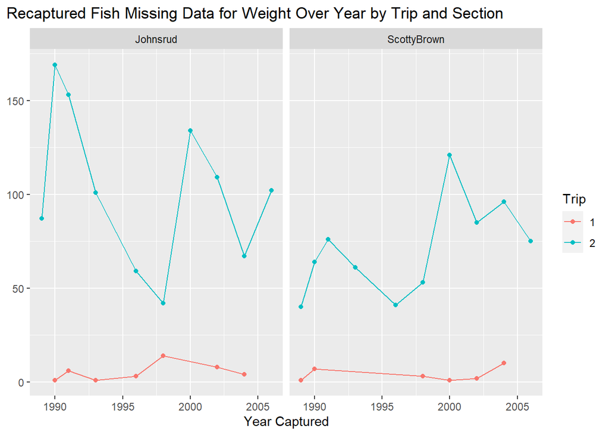

```r
recapture_missing <- recapture_data |>
  filter(is.na(weight))

recapture_missing |>
  group_by(year, trip, section) |>
  summarize(count = n()) |>
  ggplot(mapping = aes(x = year, y = count, color = trip)) +
    geom_line() +
    geom_point() +
    facet_wrap(~ section) +
    labs(
      x = "Year Captured",
      y = NULL,
      color = "Trip",
      title = "Recaptured Fish Missing Data for Weight Over Year by Trip and Section"
    ) +
    theme(
      plot.title.position = "plot"
    )
```

# 3: Part 2: Adjusting the Data (Function Writing)

## 3.1 Writing a Function

```r
rescale_01 <- function(vec) {
  stopifnot(is.numeric(vec), length(vec) > 1)
  #vec <- vec[!is.na(vec)]
  v_min <- min(vec, na.rm = TRUE)
  v_max <- max(vec, na.rm = TRUE)

  vec <- (vec - v_min) / (v_max - v_min)

  return(vec)
}
```

## 3.2 Adding Stops

Added above ^

## 3.3 Performing a Simple Test

```r
x <- c(1:85, NA)

rescale_01(x)
```

```
 [1] 0.00000000 0.01190476 0.02380952 0.03571429 0.04761905 0.05952381
 [7] 0.07142857 0.08333333 0.09523810 0.10714286 0.11904762 0.13095238
[13] 0.14285714 0.15476190 0.16666667 0.17857143 0.19047619 0.20238095
[19] 0.21428571 0.22619048 0.23809524 0.25000000 0.26190476 0.27380952
[25] 0.28571429 0.29761905 0.30952381 0.32142857 0.33333333 0.34523810
[31] 0.35714286 0.36904762 0.38095238 0.39285714 0.40476190 0.41666667
[37] 0.42857143 0.44047619 0.45238095 0.46428571 0.47619048 0.48809524
[43] 0.50000000 0.51190476 0.52380952 0.53571429 0.54761905 0.55952381
[49] 0.57142857 0.58333333 0.59523810 0.60714286 0.61904762 0.63095238
[55] 0.64285714 0.65476190 0.66666667 0.67857143 0.69047619 0.70238095
[61] 0.71428571 0.72619048 0.73809524 0.75000000 0.76190476 0.77380952
[67] 0.78571429 0.79761905 0.80952381 0.82142857 0.83333333 0.84523810
[73] 0.85714286 0.86904762 0.88095238 0.89285714 0.90476190 0.91666667
[79] 0.92857143 0.94047619 0.95238095 0.96428571 0.97619048 0.98809524
[85] 1.00000000         NA
```

## 3.4 Performing a More Difficult Test

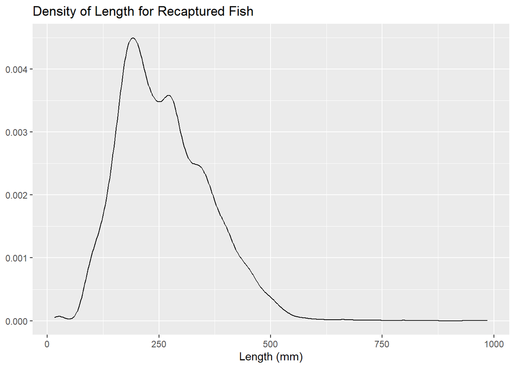

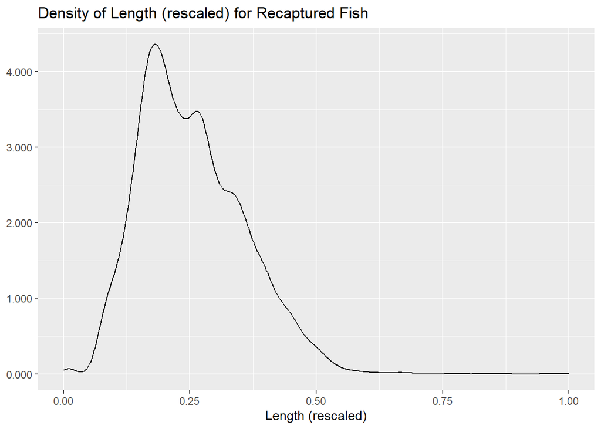

```r
recapture_scaled <- recapture_data |>
  mutate(length_scaled = rescale_01(length))

recapture_scaled |>
  ggplot(mapping = aes(x = length)) +
    geom_density() +
    labs(
      x = "Length (mm)",
      y = NULL,
      title = "Density of Length for Recaptured Fish"
    )
recapture_scaled |>
  ggplot(mapping = aes(x = length_scaled)) +
    geom_density() +
    scale_y_continuous(
      labels = function(x) format(x, nsmall = 3)
    ) +
    labs(
      x = "Length (rescaled)",
      y = NULL,
      title = "Density of Length (rescaled) for Recaptured Fish"
    )
```

nsmall function to show more decimal places: https://stackoverflow.com/questions/38722202/how-do-i-change-the-number-of-decimal-places-on-axis-labels-in-ggplot2

## 3.5 Incorporating Variables

```r
rescale_column <- function(data, variables) {
  stopifnot(is.data.frame(data))

  data <- data |>
    mutate(across(
      .cols = {{ variables }},
      .fns = ~ rescale_01(.x)
    ))

  return(data)

}
```

## 3.6 Another Function Test

```r
recapture_rescale <- rescale_column(recapture_data, length:weight)

recapture_rescale
```

```
# A tibble: 18,352 × 7
   trip   mark length  weight  year section  species
   <fct> <dbl>  <dbl>   <dbl> <dbl> <fct>    <fct>
 1 1         0  0.280 0.0374   1989 Johnsrud RBT
 2 1         0  0.280 0.0406   1989 Johnsrud RBT
 3 1         0  0.277 0.0524   1989 Johnsrud RBT
 4 1         0  0.315 0.0588   1989 Johnsrud RBT
 5 1         0  0.305 0.0641   1989 Johnsrud RBT
 6 1         0  0.358 0.0812   1989 Johnsrud RBT
 7 1         0  0.261 0.0363   1989 Johnsrud RBT
 8 1         0  0.148 0.00855  1989 Johnsrud RBT
 9 1         0  0.203 0.0171   1989 Johnsrud RBT
10 1         0  0.145 0.00748  1989 Johnsrud RBT
# … with 18,342 more rows
```